# Stan models

Gilles Lijnzaad

2026-04-07

# Helper files

In this R markdown I use code from the following files: [sim.R](https://gilleslijnzaad.github.io/climate-RL-modeling/all_utils.html#simR), [plot_utils.R](https://gilleslijnzaad.github.io/climate-RL-modeling/all_utils.html#plot_utilsR), [fit_utils.R](https://gilleslijnzaad.github.io/climate-RL-modeling/all_utils.html#fit_utilsR), and [utils.R](https://gilleslijnzaad.github.io/climate-RL-modeling/all_utils.html#utilsR).

# 1 The data

## 1.1 Running the simulation

For the full simulation code, see `run_std()` in [sim.R](https://gilleslijnzaad.github.io/climate-RL-modeling/all_utils.html#simR).

```r
rm(list = ls())
setwd("~/research/climate-RL-mod/stan_models")
main_dir <- "~/research/climate-RL-mod/"
sim_dir <- paste0(main_dir, "R_simulation/")

sim <- new.env()
source(paste0(sim_dir, "sim.R"), local = sim) # access functions using sim$fun()

params <- list(
  n_part = 50,
  n_trials = 30,
  LR_group = 0.4,
  inv_temp_group = 0.5,
  initQF_group = 8,
  initQU_group = 2,
  mu_R_group = list(F = 5, U = 5),
  sigma_R_group = 2
)

sim_dat <- sim$run_std(params)

cat(paste0("PARAMETER SETTINGS:"), capture.output(dplyr::glimpse(params)), sep = "\n")
```

```
PARAMETER SETTINGS:
List of 8
 $ n_part        : num 50
 $ n_trials      : num 30
 $ LR_group      : num 0.4
 $ inv_temp_group: num 0.5
 $ initQF_group  : num 8
 $ initQU_group  : num 2
 $ mu_R_group    :List of 2
  ..$ F: num 5
  ..$ U: num 5
 $ sigma_R_group : num 2
```

```r
cat(paste0("SIMULATED DATA:"), capture.output(dplyr::glimpse(sim_dat)), sep = "\n")
```

```
SIMULATED DATA:
Rows: 1,500
Columns: 8
$ participant <int> 1, 1, 1, 1, 1, 1, 1, 1, 1, 1, 1, 1, 1, 1, 1, 1, 1, 1, 1, 1…
$ trial       <int> 1, 2, 3, 4, 5, 6, 7, 8, 9, 10, 11, 12, 13, 14, 15, 16, 17,…
$ Q_F         <dbl> 3.308605, 3.576838, 3.961119, 3.967285, 3.967285, 3.967285…
$ Q_U         <dbl> 2.858249, 2.858249, 2.858249, 2.858249, 3.039316, 2.874494…
$ choice      <dbl> 1, 1, 1, 2, 2, 1, 1, 1, 1, 1, 1, 1, 1, 1, 1, 1, 1, 1, 1, 1…
$ R           <dbl> 5, 6, 4, 4, 2, 6, 7, 8, 6, 6, 6, 5, 6, 6, 7, 6, 7, 5, 7, 5…
$ LR          <dbl> 0.1585869, 0.1585869, 0.1585869, 0.1585869, 0.1585869, 0.1…
$ inv_temp    <dbl> 0.5832288, 0.5832288, 0.5832288, 0.5832288, 0.5832288, 0.5…
```

## 1.2 Inspecting the data

Just so I know what to expect of our model, I include plots of the simulated data: Q values and choices over time.

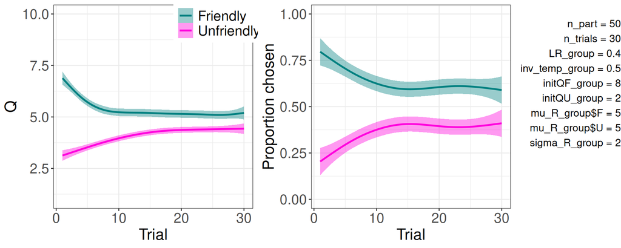

```r
plot <- new.env()
source(paste0(main_dir, "plot_utils.R"), local = plot) # access functions using plot$fun()

plot$sim_plots(sim_dat, params)
```

# 2 Explaining the model

I show the Stan model code bit by bit to explain what is happening. The full code can be found in climate-RL.stan.

## 2.1 `data` block

The data we supply to the model consist of:

1. the number of participants: `n_part`;
2. the number of trials per participant: `n_trials`;
3. an array of choices that a participant made: `choice[n_part, n_trials]`;
4. an array of ratings that a participant gave: `R[n_part, n_trials]`. These are analogous to the array `outcomes[n_trials]` in the `2arm_bandit_example` (see [Stan code](https://github.com/CCS-Lab/hBayesDM/blob/develop/commons/stan_files/bandit2arm_delta.stan) for this example).

```r
mod_code <- readLines("climate-RL.stan")
start <- grep("data \\{", mod_code)[1]
end <- grep("transformed data \\{", mod_code) - 2
cat(mod_code[start:end], sep = "\n")
```

```
data {
  int<lower=1> n_part;
  int<lower=1> n_trials;
  array[n_part, n_trials] int<lower=1, upper=2> choice;
  array[n_part, n_trials] int<lower=1, upper=10> R;
}
```

## 2.2 `transformed data` block

Currently unused.

```r
start <- grep("transformed data \\{", mod_code)
end <- grep("parameters \\{", mod_code)[1] - 2
cat(mod_code[start:end], sep = "\n")
```

[output not shown]

## 2.3 `parameters` block

In the current model, we have four free parameters:

1. learning rate;
2. inverse temperature;
3. initial Q for friendly;
4. initial Q for unfriendly.

```r
start <- grep("parameters \\{", mod_code)[1]
end <- grep("transformed parameters \\{", mod_code) - 2
cat(mod_code[start:end], sep = "\n")
```

```
parameters {
  // group-level parameters
  vector[4] means_probit;
  vector<lower=0>[4] sigmas;

  // participant-level parameters
  vector[n_part] LR_probit;
  vector[n_part] inv_temp_probit;
  vector[n_part] initQF_probit;
  vector[n_part] initQU_probit;
}
```

## 2.4 `transformed parameters` block

```r
start <- grep("transformed parameters \\{", mod_code)
end <- grep("model \\{", mod_code) - 2
cat(mod_code[start:end], sep = "\n")
```

[output not shown]

## 2.5 `model` block

### 2.5.1 The priors

```r
start <- grep("model \\{", mod_code)
end <- grep("participant loop", mod_code)[1] - 2
cat(mod_code[start:end], sep = "\n")
```

```
model {
  // priors
  means_probit ~ normal(0, 1);
  sigmas ~ normal(0, 0.2);

  LR_probit ~ normal(0, 1);
  inv_temp_probit ~ normal(0, 1);
  initQF_probit ~ normal(0, 1);
  initQU_probit ~ normal(0, 1);
```

### 2.5.2 Participant loop

For every participant I initialize an array for holding the Q values. I also create a temporary vector `Q_t` that holds the two Q values (F, U) for the *current* trial, because otherwise the `categorical_logit` wouldn’t work, somehow. This works for now, and maybe in the future I will find a more elegant solution.

```r
start <- grep("participant loop", mod_code) + 1
end <- grep("trial loop", mod_code) - 2
cat(mod_code[start:end], sep = "\n")
```

```
  for (j in 1:n_part) {

    // initialization
    array[n_trials, 2] real Q;
    Q[1, 1] = initQF[j];
    Q[1, 2] = initQU[j];
    vector[2] Q_t;
    real pred_err;
```

### 2.5.3 Trial loop

```r
start <- grep("trial loop", mod_code) + 1
end <- grep("generated quantities", mod_code) - 2
cat(mod_code[start:end], sep = "\n")
```

```
    for (t in 1:n_trials) {
      Q_t = to_vector(Q[t]);

      // sample choice (1 is F, 2 is U) via softmax
      choice[j, t] ~ categorical_logit(inv_temp[j] * Q_t);

      // prediction error
      pred_err = R[j, t] - Q[t, choice[j, t]];

      // update value (learn)
      if (t < n_trials) {    // no updating in the very last trial
        if (choice[j, t] == 1) {
          Q[t+1, 1] = Q[t, 1] + LR[j] * pred_err;
          Q[t+1, 2] = Q[t, 2];
        } else {
          Q[t+1, 1] = Q[t, 1];
          Q[t+1, 2] = Q[t, 2] + LR[j] * pred_err;
        }
      }
    }
  }
}
```

## 2.6 `generated quantities` block

```r
start <- grep("generated quantities", mod_code)
end <- length(mod_code)
cat(mod_code[start:end], sep = "\n")
```

```
generated quantities {
  vector[4] means;
  means[1] = Phi_approx(means_probit[1]);
  means[2] = Phi_approx(means_probit[2]) * 5;
  means[3] = Phi_approx(means_probit[3]) * 9 + 1;
  means[4] = Phi_approx(means_probit[4]) * 9 + 1;
}
```

# 3 Fitting the model

## 3.1 Single run (demo)

### 3.1.1 Do the run

To save running time, I only refit the model if I changed the model or if the simulated data have changed (i.e., if I changed parameter settings). To this end, I compare the previously saved `sim_data.json` to the current `sim_dat`. After this comparison, I can save the new `sim_data` and refit the model if necessary.

```r
dat_dir <- paste0(main_dir, "stan_models/dat/1_runs/")
dat_file <- paste0(dat_dir, "sim_dat_001.json")

dat_changed <- sim$did_sim_dat_change(dat_file, sim_dat)
sim$save_sim_dat(params, sim_dat, dat_file)
model_changed <- FALSE

fitting <- new.env()
source(paste0(main_dir, "stan_models/fit_utils.R"), local = fitting) # access functions using fitting$fun()
if (dat_changed | model_changed) {
  model <- cmdstan_model("climate-RL.stan")
  draws <- fitting$get_draws(model, dat_file, show_iteration_progress = TRUE)
  saveRDS(draws, paste0(dat_dir, "fit_001.rds"))
} else {
  draws <- readRDS(file = paste0(dat_dir, "fit_001.rds"))
}
```

### 3.1.2 Group-level parameter recovery

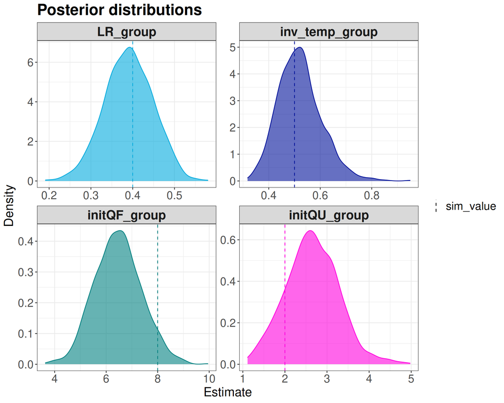

```r
to_inspect <- c("LR_group", "inv_temp_group", "initQF_group", "initQU_group")
plot$posterior_density(draws, to_inspect, params)
```

```r
util <- new.env()
source(paste0(main_dir, "utils.R"), local = util) # access functions using util$fun()
util$print_posterior_table(draws, params, to_inspect)
```

Posteriors for free parameters

| Parameter | Simulated value | Median [95% credibility interval] |
| --- | --- | --- |
| LR_group | 0.4 | 0.39 [0.28, 0.50] |
| inv_temp_group | 0.5 | 0.51 [0.37, 0.70] |
| initQF_group | 8.0 | 6.45 [4.79, 8.27] |
| initQU_group | 2.0 | 2.64 [1.43, 3.97] |

### 3.1.3 Participant-level parameter recovery

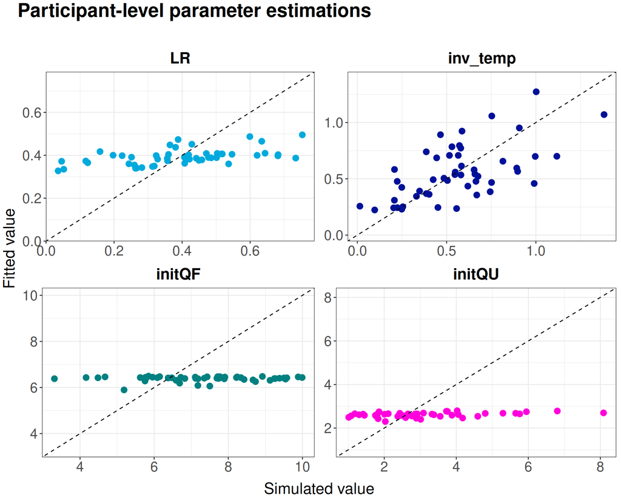

```r
participant_params <- rjson::fromJSON(file = paste0(dat_dir, "sim_param_settings_001.json"))
plot$pp_level_param_fit(draws, c("LR", "inv_temp", "initQF", "initQU"), participant_params)
```

Strange: for inv_temp it seems okay, but for the other parameters the participant-level estimations are very similar to the group-level estimations.

## 3.2 Many runs

To check parameter recovery across a range of parameter values, I run the model a bunch of times with different parameter settings. More specifically, each parameter value is chosen randomly from its whole theoretical range.

```r
n_runs <- 10
free_params <- c("LR_group", "inv_temp_group", "initQF_group", "initQU_group")

# fitting$sim_fit_many(params, free_params, "climate-RL.stan", n_runs)
```

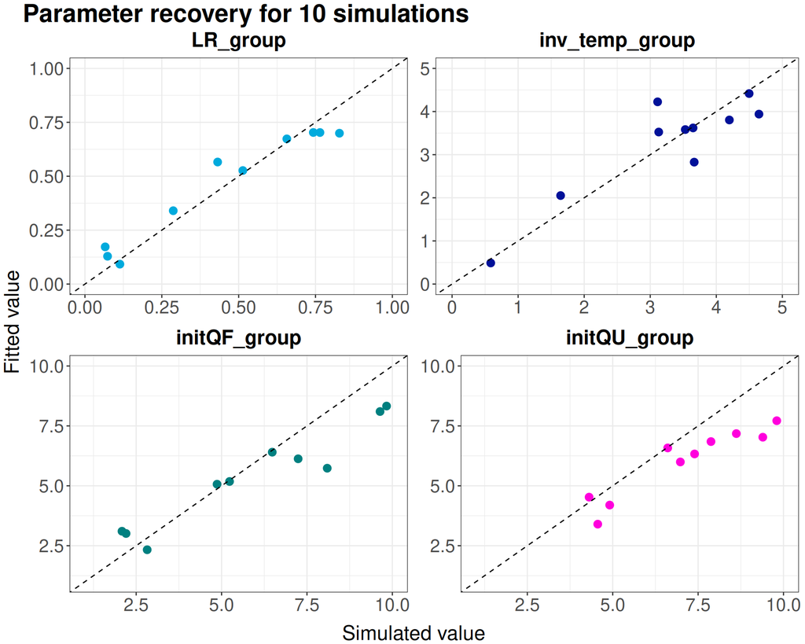

```r
sim_params <- data.frame(k = 1:n_runs)
fit_params <- data.frame(k = 1:n_runs)

dat_dir <- paste0(main_dir, "stan_models/dat/10_runs/")

for (k in 1:n_runs) {
  sim_file <- paste0(dat_dir, "sim_param_settings_", sprintf("%03d", k), ".json")
  sim_dat <- rjson::fromJSON(file = sim_file)

  fit_file <- paste0(dat_dir, "fit_", sprintf("%03d", k), ".rds")
  fit_dat <- readRDS(fit_file)

  # calculate medians
  for (p in free_params) {
    sim_params[[p]][k] <- sim_dat[[p]]
    fit_params[[p]][k] <- median(fit_dat[[p]])
  }
}

plot$many_runs_param_fit(sim_params, fit_params, free_params)
```